# Experiential Data science for Undergraduate Cross-disciplinary Education

UBC JupyterDay 2018

[figure not shown]

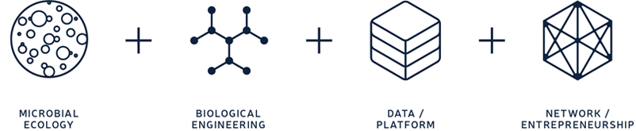

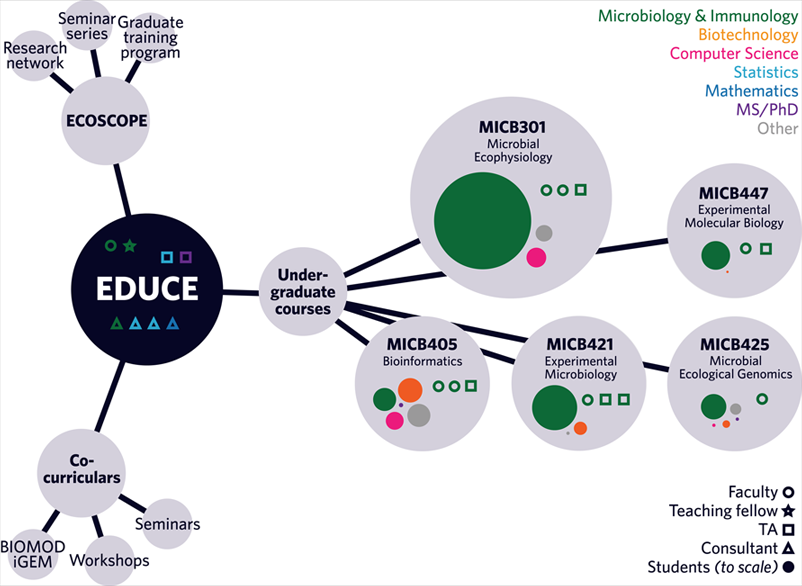

## Course modules

- Data science in microbiology
- Command line
- R/RStudio
  - Working with data
  - Graphics with ggplot
  - Rmarkdown
- Statistics
- Git/GitHub
  - Version control
  - Collaboration
- Sequence analysis tools

## Workshops

- Introduction to R
- The R tidyverse
- Statistical models in R
- Intermediate R programming
- Reproducible research
- Exploring the phylogenetic composition of microbiomes
- Compute Canada
- Software Carpentry

## Key aspects

- Connections to domain knowledge and questions
- Hands-on practice
- Accessible and open-source
- Peer teaching
- Courses connect with co-curriculars (like workshops)

## Example modules

- Microbial ecology plots with ggplot and phyloseq
- Introduction to Git/GitHub

Available at https://github.com/EDUCE-UBC/MICB425/tree/master/data_science_Friday/tutorials

## Moving forward

- Transition from Rmarkdown to Jupyter Notebooks
- Integrate auto-graded code assessment for exercises
- Screen capture video content
- Additional courses and co-curriculars

## Access to materials

[GitHub](https://github.com/orgs/EDUCE-UBC/dashboard)

[Course knitter](https://educe-ubc.github.io/)

## Acknowledgements

- Steven Hallam (MICB)
- EDUCE TAs
  - 2018/19: David Yin (CPSC/STAT), Nolan Shelley (BIOL, botany), Yue Liu (MATH)
  - 2017/18: Lisa McEwen (CMMT), Kris Hong (STAT)
- Course instructors
  - 2018/19: Jae-Hyeok Lee (BIOL, botany)
  - 2017-19: Bill Mohn (MICB), Dave Oliver (MICB), Martin Hirst (MICB)
- Course TAs
  - 2017/18: Connor Morgan-Laang (BINFO), Joe Ho (MICB)
- Funding
  - UBC TLEF, MICB, Skylight, ECOSCOPE, MRN